# Viaje por Argentina

Para este ejercicio queremos encontrar el camino más eficiente para recorrer todas las capitales de Argentina, es decir, encontrar aquel recorrido que minimice de manera aproximada la cantidad de km a recorrer para visitar una vez todas las capitales, y volver a la primera. Para esto, utilizaremos tres algortimos heurísiticos: Nearest Neighbor Algorithm (NNA), Repetitve Nearest Neighbor Algorithm (RNNA) y Cheapest-link Algorithm (CLA).Estos tres son algoritmos de aproximación, que no buscan el resultado óptimo, sino más bien una buena aproximación a un buen costo computacional.

```r
head(capital, n = Inf)
```

| Provincia | Capital | Latitud | Longitud |
| --- | --- | --- | --- |
| Buenos Aires | La Plata | -34.9214 | -57.9544 |
| Catamarca | San Fernando del Valle de Catamarca | -28.4696 | -65.7795 |
| Chaco | Resistencia | -27.4512 | -58.9864 |
| Chubut | Rawson | -43.3002 | -65.1023 |
| Córdoba | Córdoba | -31.4201 | -64.1888 |
| Corrientes | Corrientes | -27.4692 | -58.8307 |
| Entre Ríos | Paraná | -31.7319 | -60.5238 |
| Formosa | Formosa | -26.1849 | -59.1731 |
| Jujuy | San Salvador de Jujuy | -24.1858 | -65.2995 |
| La Pampa | Santa Rosa | -36.6203 | -64.2998 |

[output cut: 13 more lines]

Vemos todas las capitales provinciales. Pero no voy a requerir la primera columna, con el nombre de la provincia, por lo que

```r
capital_2 <- as.data.frame(select(capital, -Provincia))
head(capital_2)
```

|  | Capital | Latitud | Longitud |
| --- | --- | --- | --- |
| 1 | La Plata | -34.9214 | -57.9544 |
| 2 | San Fernando del Valle de Catamarca | -28.4696 | -65.7795 |
| 3 | Resistencia | -27.4512 | -58.9864 |
| 4 | Rawson | -43.3002 | -65.1023 |
| 5 | Córdoba | -31.4201 | -64.1888 |
| 6 | Corrientes | -27.4692 | -58.8307 |

Luego, tomo las latitudes y longitudes para crear una matriz de distancias usando la fórmula de Haversine.

```r
distancias <- distm(capital_2[, c("Latitud", "Longitud")], fun = distHaversine)
```

Luego de crear la matriz con las distancias entre capitales, debemos transformar al objeto en formato TSP (en Kilómetros)

```r
distancias_tsp <- TSP(distancias)/1000
```

Ahora utilizaré los algortimos heurísticos para resolver este problema:

```r
viaje_nna <- solve_TSP(distancias_tsp, method = "nn")
NNA <- tour_length(viaje_nna)
viaje_rnna <- solve_TSP(distancias_tsp, method = "repetitive_nn")
RNNA <- tour_length(viaje_rnna)
viaje_cla <- solve_TSP(distancias_tsp, method = "cheapest_insertion")
CLA <- tour_length(viaje_cla)

comparacion_km <- data.frame(NNA, RNNA, CLA)
rownames(comparacion_km) <- "KM"
round(t(comparacion_km),2)
```

```
##           KM
## NNA  6940.22
## RNNA 6474.41
## CLA  5759.75
```

Si queremos cómo ordena las ciudades cada algortimo hacemos:

```r
orden_nna <- capital_2[c(viaje_nna, viaje_nna[1]),]
orden_nna
```

|  | Capital | Latitud | Longitud |
| --- | --- | --- | --- |
| 17 | San Juan | -31.5375 | -68.5364 |
| 12 | Mendoza | -32.8895 | -68.8458 |
| 14 | Neuquén | -38.9516 | -68.0591 |
| 18 | San Luis | -33.2996 | -66.3390 |
| 11 | La Rioja | -29.4135 | -66.8557 |
| 2 | San Fernando del Valle de Catamarca | -28.4696 | -65.7795 |
| 23 | San Miguel de Tucumán | -26.8320 | -65.2049 |
| 16 | Salta | -24.7821 | -65.4232 |
| 9 | San Salvador de Jujuy | -24.1858 | -65.2995 |
| 21 | Santiago del Estero | -27.7951 | -64.2615 |

[output cut: 14 more lines]

```r
orden_rnna <- capital_2[c(viaje_rnna, viaje_rnna[1]),]
orden_rnna
```

|  | Capital | Latitud | Longitud |
| --- | --- | --- | --- |
| 20 | Santa Fé | -31.6333 | -60.7000 |
| 7 | Paraná | -31.7319 | -60.5238 |
| 3 | Resistencia | -27.4512 | -58.9864 |
| 6 | Corrientes | -27.4692 | -58.8307 |
| 8 | Formosa | -26.1849 | -59.1731 |
| 13 | Posadas | -27.3671 | -55.8961 |
| 1 | La Plata | -34.9214 | -57.9544 |
| 15 | Viedma | -40.8110 | -62.9967 |
| 10 | Santa Rosa | -36.6203 | -64.2998 |
| 5 | Córdoba | -31.4201 | -64.1888 |

[output cut: 14 more lines]

```r
orden_cla <- capital_2[c(viaje_cla, viaje_cla[1]),]
orden_cla
```

|  | Capital | Latitud | Longitud |
| --- | --- | --- | --- |
| 4 | Rawson | -43.3002 | -65.1023 |
| 22 | Ushuahia | -54.8019 | -68.3029 |
| 19 | Río Gallegos | -51.6230 | -69.2168 |
| 14 | Neuquén | -38.9516 | -68.0591 |
| 12 | Mendoza | -32.8895 | -68.8458 |
| 17 | San Juan | -31.5375 | -68.5364 |
| 18 | San Luis | -33.2996 | -66.3390 |
| 11 | La Rioja | -29.4135 | -66.8557 |
| 2 | San Fernando del Valle de Catamarca | -28.4696 | -65.7795 |
| 16 | Salta | -24.7821 | -65.4232 |

[output cut: 14 more lines]

Lo vemos en un cuadro comparativo:

```r
comparacion_recorrido <- data.frame(NNA = orden_nna$Capital, RNNA = orden_rnna$Capital, CLA = orden_cla$Capital)
comparacion_recorrido
```

| NNA | RNNA | CLA |
| --- | --- | --- |
| San Juan | Santa Fé | Rawson |
| Mendoza | Paraná | Ushuahia |
| Neuquén | Resistencia | Río Gallegos |
| San Luis | Corrientes | Neuquén |
| La Rioja | Formosa | Mendoza |
| San Fernando del Valle de Catamarca | Posadas | San Juan |
| San Miguel de Tucumán | La Plata | San Luis |
| Salta | Viedma | La Rioja |
| San Salvador de Jujuy | Santa Rosa | San Fernando del Valle de Catamarca |
| Santiago del Estero | Córdoba | Salta |

[output cut: 14 more lines]

Graficamos el recorrido con cada algortimo:

- NNA:

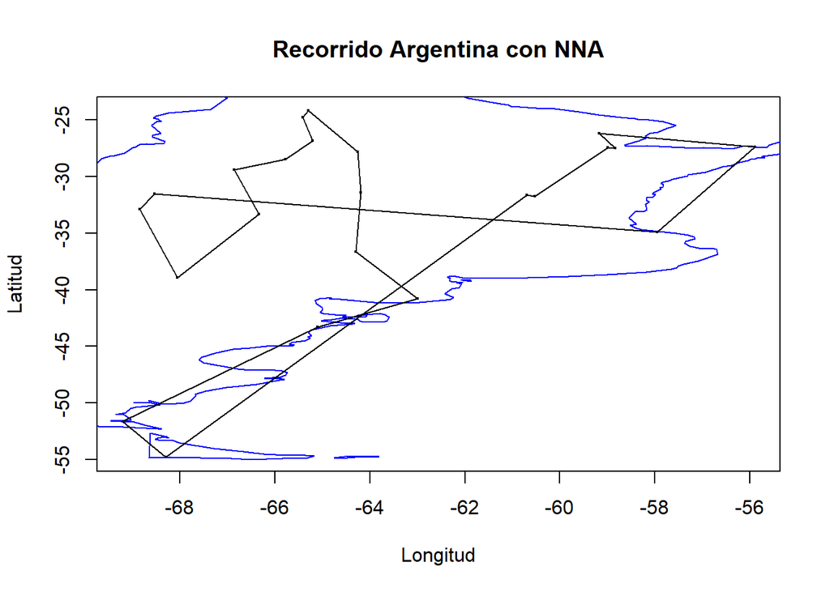

```r
mapa_arg_nna <- function () {
plot((capital_2[,c("Longitud", "Latitud")]), cex = .3, main = "Recorrido Argentina con NNA")
map("world", regions = "Argentina", col = "blue", fill = FALSE, add = TRUE)
polygon(capital_2[ ,c("Longitud", "Latitud")][viaje_nna, ], border = "black")
}

mapa_arg_nna()
```

- RNNA:

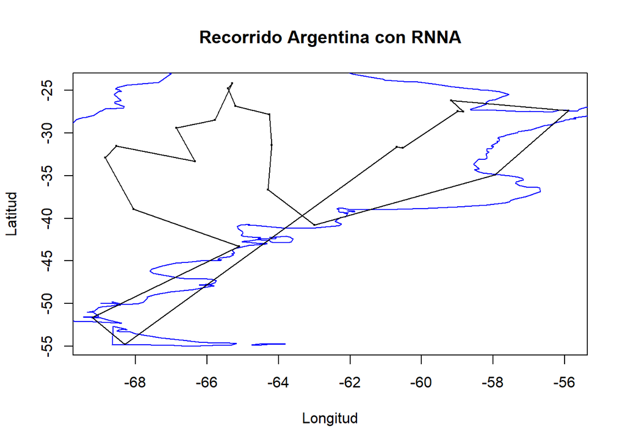

```r
mapa_arg_rnna <- function () {
plot((capital_2[,c("Longitud", "Latitud")]), cex = .3, main = "Recorrido Argentina con RNNA")
map("world", regions = "Argentina", col = "blue", fill = FALSE, add = TRUE)
polygon(capital_2[ ,c("Longitud", "Latitud")][viaje_rnna, ], border = "black")
}

mapa_arg_rnna()
```

- CLA:

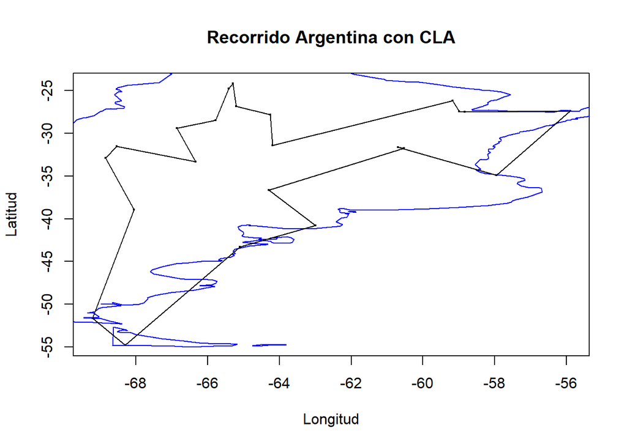

```r
mapa_arg_cla <- function () {
plot((capital_2[,c("Longitud", "Latitud")]), cex = .3, main = "Recorrido Argentina con CLA")
map("world", regions = "Argentina", col = "blue", fill = FALSE, add = TRUE)
polygon(capital_2[ ,c("Longitud", "Latitud")][viaje_cla, ], border = "black")
}

mapa_arg_cla()
```

En conlusión, obtenemos que el menor recorrido posible para pasar una vez por todas las capitales de Argentina es el propuesto por el algortimo CLA, el cual tiene un recorrido menor que RNNA (y por extensión NNA). A pesar de que en cada ejecución el recorrido final varía, se mantiene que CLA < RNNA <= NNA.